# MATH 340: Discrete Random Variables

Hitchman

# Homemade Distributions

Let’s say a discrete random variable $X$ has finite sample space and known probability function $p(x)$. We often display this type of probability model via a table:

| $x$ | 5 | 6 | 7 | 8 | 9 |
| --- | --- | --- | --- | --- | --- |
| $p(x)$ | 0.1 | 0.1 | 0.3 | 0.4 | 0.1 |

## Input the model

We can input this model into an RStudio session by defining two vectors:

```r
X=c(5,6,7,8,9)
Px=c(0.1,0.1,0.3,0.4,0.1)
```

Is this a *valid* probablity model?

```r
Px >= 0
```

```
## [1] TRUE TRUE TRUE TRUE TRUE
```

Ok, each probability is greater than or equal to 0… and

```r
sum(Px)
```

```
## [1] 1
```

So… all the probabilities are non-negative and $\displaystyle \sum_{\text{all } x}p(x) = 1$, so, yes, we have a valid probability model.

## Expected Value of $X$

Recall if $X$ is a discrete random variable with probability function $p(x)$, then the expected value of $X$ is
$$E(X)=\sum_{\text{all }x}x\cdot p(x)$$

**In R**, if `v` and `w` are two vectors of equal length, then the command `v*w` produces a new vector whose entries are the component-wise products of `v` and `w`:

```r
v=c(2,5)
w=c(3,-1)
v*w
```

```
## [1]  6 -5
```

So having defined $X$ and $Px$, we can compute $E(X)$ by running

```r
sum(X*Px)
```

```
## [1] 7.3
```

Note: For those who have taken vector calculus, for two vectors `v` and`w` of equal length, `sum(v*w)` returns the dot product, aka the inner product. R has an alternative command for this dot product, which is `v %*% w`. So, `sum(v*w)` and `v %*% w` do the same thing, but I prefer the first option to remind me that the expected value is obtained as a sum over all x of some things.

## Variance of $X$

Recall the variance of $X$ is
$$V(X) = E[(X-\mu)^2],$$
where $\mu = E(X)$. Alternatively, the variance can also be computed as
$$V(X) =
E(X^2)-\mu^2.$$

R makes an easy job of running each value of a vector $v$ through some function, and recording all the results in a new vector:

```r
v = c(-2,0,1,2)
v^2
```

```
## [1] 4 0 1 4
```

With that in mind, we can crank out $V(X)$ as follows:

```r
mu=sum(X*Px)
Vx=sum((X-mu)^2*Px)
print(paste0("The mean of X is ",mu,", and the variance of X is ",Vx ))
```

```
## [1] "The mean of X is 7.3, and the variance of X is 1.21"
```

## Visualize the model

**In base R** we offer some quick looks

The following code will give the shape of the distribution without labeling the x values

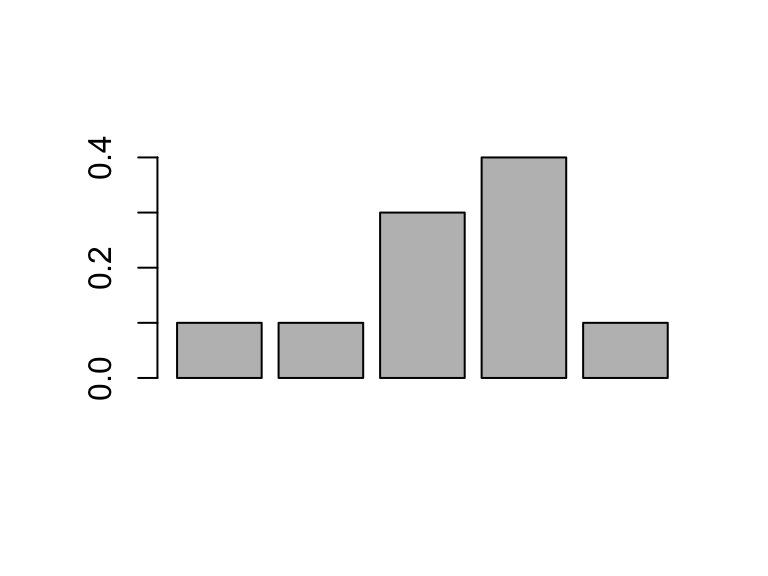

```r
barplot(Px)
```

We can include the $x$-values (and give a splash of color, and plot title) as follows

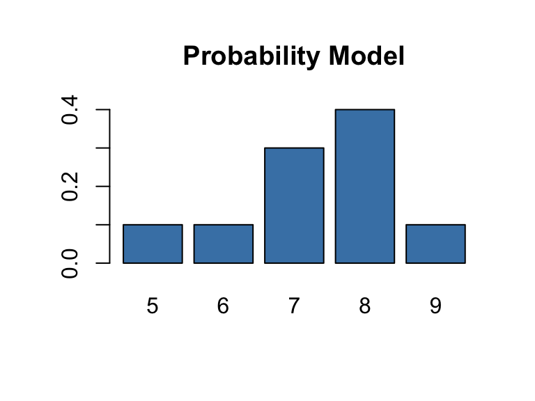

```r
barplot(Px,names.arg=X, col="steelblue", main="Probability Model")
```

## Sampling from the model

The following code draws a random sample of size 10 from our distribution.

```r
sample(X,10,replace=TRUE,prob=Px)
```

```
##  [1] 7 8 7 5 8 5 6 9 8 8
```

If we take a large sample, and make a frequency plot of the results, it should be close to the shape of the Px plot above.

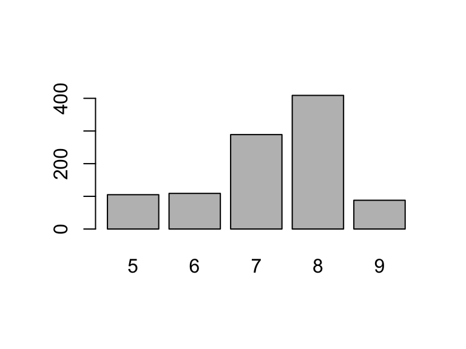

```r
trials=1000
results=table(sample(X,trials,replace=TRUE,Px))
barplot(results)
```

And we can also make a relative frequency plot for our sample, which should match the plot of the probability model itself, when our sample size is large.

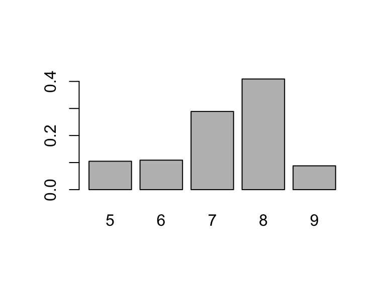

```r
barplot(results/trials)
```

# Uniform Distribution

Suppose we want to draw one element from a set at random, and all elements have equal probability of being drawn. The associated probability distribution is called **uniform**.

> **Example**: Pick a random seal from the famous family of 6: Otto, Ruth, Pluotika, Slarftel, Edgar and Bob.

```r
family=c("Bob", "Edgar", "Pluotika", "Otto", "Ruth", "Slarftel")
sample(family,1)
```

```
## [1] "Pluotika"
```

In a uniform distribution, we will find over a large number of trials that each name comes up with about the same frequency, so the bars of a frequency plot will all be about the same height. To simulate a large number of draws, make sure to **sample with replacement**.

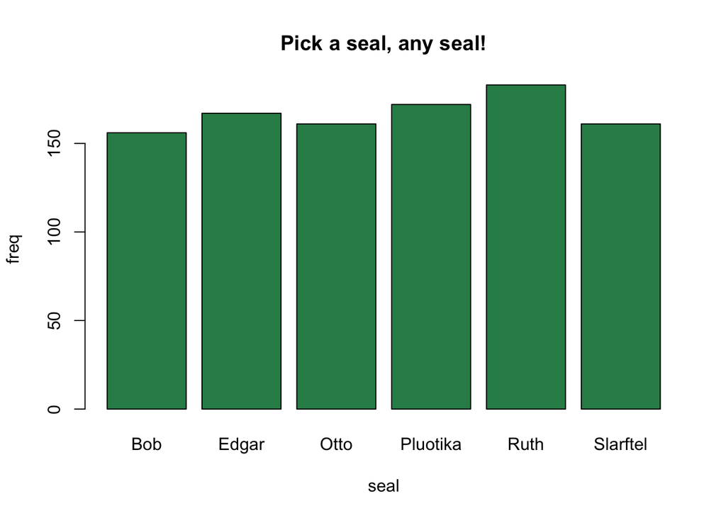

```r
results=sample(family,1000,replace=TRUE)
barplot(table(results),col="seagreen",xlab="seal",ylab="freq",main="Pick a seal, any seal!")
```

Way to go Ruth, you overachiever!